**Unidad 02:** Probabilidad e inferencia estadística  
**Asignatura:** Métodos y simulación estadística  
Maestría en Ciencia de datos  
Pontificia Universidad Javeriana

- Inicio

# Problema 03: Teorema del Límite Central

## Planteamiento:

El Teorema del Límite Central es uno de los más importantes en la inferencia estadística y habla sobre la convergencia de los estimadores como la proporción muestral a la distribución normal. Algunos autores afirman que esta aproximación es bastante buena a partir del umbral n>30.  
A continuación se describen los siguientes pasos para su verificación:

## Pasos y Solución:

##### 1. Realice una simulación en la cual genere una población de n=1000 (Lote), donde el porcentaje de individuos (supongamos plantas) enfermas sea del 50%.

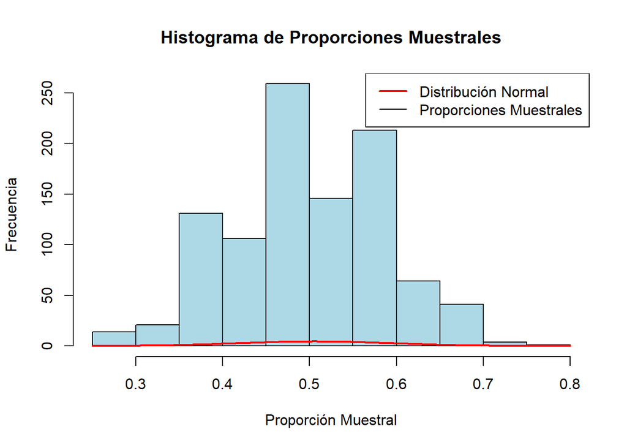

```r
# Establecer la semilla para reproducibilidad
set.seed(123)

# Tamaño de la población
n_poblacion <- 1000

# Porcentaje de plantas enfermas en la población (50%)
proporcion_enfermas <- 0.5

# Tamaño de muestra
n_muestra <- 30  # Puedes cambiar este valor según tu umbral

# Realizar simulación
muestras <- matrix(NA, nrow = 1000, ncol = n_muestra)

for (i in 1:1000) {
	muestra <- sample(c(0, 1), size = n_muestra, replace = TRUE, prob = c(1 - proporcion_enfermas, proporcion_enfermas))
	muestras[i, ] <- muestra
}

# Calcular la proporción muestral para cada muestra
proporciones_muestrales <- rowMeans(muestras)

# Histograma de las proporciones muestrales
hist(proporciones_muestrales, main = "Histograma de Proporciones Muestrales",
xlab = "Proporción Muestral", ylab = "Frecuencia", col = "lightblue")

# Ajuste de una distribución normal
curve(dnorm(x, mean = mean(proporciones_muestrales), sd = sd(proporciones_muestrales)),
	col = "red", lwd = 2, add = TRUE)

# Leyenda
legend("topright", legend = c("Distribución Normal", "Proporciones Muestrales"), col = c("red", "black"), lwd = c(2, 1))
```

##### 2. Genere una función que permita:

- Obtener una muestra aleatoria de la población y
- Calcule el estimador de la proporción muestral pˆ para un tamaño de muestra dado n

```r
# Muestra y estimador de la proporción muestral
obtener_muestra_y_phat <- function(n, proporcion_enfermas) {
	muestra <- sample(c(0, 1), size = n, replace = TRUE, prob = c(1 - proporcion_enfermas, proporcion_enfermas))
	phat <- sum(muestra) / n
	return(phat)
}

# Ejemplo para una muestra 30
tamanio_muestra <- 30
proporcion_enfermas <- 0.5  # Porcentaje de individuos enfermos en la población (50%)
resultado <- obtener_muestra_y_phat(tamanio_muestra, proporcion_enfermas)
print(resultado)
```

```
## [1] 0.5
```

##### 3. Repita el escenario anterior (b) n=500 veces y analice los resultados en cuanto al comportamiento de los 500 resultados del estimador pˆ. ¿Qué tan simétricos o sesgados son los resultados obtenidos? y ¿qué se puede observar en cuanto a la variabilidad?. Realice en su informe un comentario sobre los resultados obtenidos.

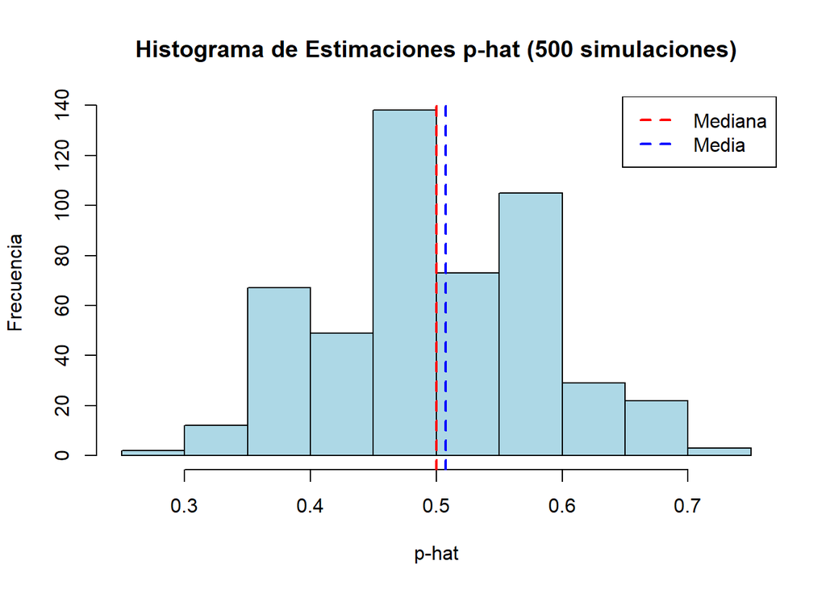

```r
# Establecer la semilla para reproducibilidad
set.seed(123)

# Parámetros
n_simulaciones <- 500
tamanio_muestra <- 30
proporcion_enfermas <- 0.5

# Vector para almacenar los resultados de p-hat
resultados_phat <- numeric(n_simulaciones)

# Realizar las simulaciones
for (i in 1:n_simulaciones) {
	muestra <- sample(c(0, 1), size = tamanio_muestra, replace = TRUE, prob = c(1 - proporcion_enfermas, proporcion_enfermas))
	phat <- sum(muestra) / tamanio_muestra
	resultados_phat[i] <- phat
}

# Histograma de los resultados de p-hat
hist(resultados_phat, main = "Histograma de Estimaciones p-hat (500 simulaciones)",
xlab = "p-hat", ylab = "Frecuencia", col = "lightblue")

# Mediana y media de los resultados de p-hat
mediana <- median(resultados_phat)
media <- mean(resultados_phat)

# Agregar líneas al histograma para la mediana y la media
abline(v = mediana, col = "red", lwd = 2, lty = 2)
abline(v = media, col = "blue", lwd = 2, lty = 2)

# Leyenda
legend("topright", legend = c("Mediana", "Media"), col = c("red", "blue"), lwd = c(2, 2), lty = c(2, 2))
```

```r
# Skewness (coeficiente de asimetría)
library(e1071)
asimetria <- skewness(resultados_phat)

# Variabilidad (desviación estándar)
desviacion_estandar <- sd(resultados_phat)

# Resultados
cat("Mediana de p-hat:", mediana, "\n")
```

```
## Mediana de p-hat: 0.5
```

```r
cat("Media de p-hat:", media, "\n")
```

```
## Media de p-hat: 0.5074667
```

```r
cat("Coeficiente de asimetría (skewness):", asimetria, "\n")
```

```
## Coeficiente de asimetría (skewness): 0.05720204
```

```r
cat("Desviación estándar de p-hat:", desviacion_estandar, "\n")
```

```
## Desviación estándar de p-hat: 0.08676517
```

##### Conclusión

Los resultados obtenidos sugieren que los estimadores de proporción muestral ($p⏜$) tienen un sesgo muy pequeño, ya que la media ($p⏜¯$) es cercana al valor teórico de la proporción poblacional ($p = 0.5$). El coeficiente de asimetría (skewness) también es muy cercano a cero (0.0572), lo que indica que la distribución de los estimadores es bastante simétrica alrededor de la media.

En cuanto a la variabilidad, la desviación estándar ($(σp⏜)$) es de 0.0868. Esto sugiere que los estimadores tienden a variar alrededor de la media, pero la magnitud de esta variabilidad es relativamente pequeña en comparación con la escala de 0 a 1 de la proporción muestral. En otras palabras, los resultados de los estimadores son bastante consistentes y no fluctúan significativamente alrededor de la proporción poblacional.

##### 4. Repita los puntos b y c para tamaños de muestra n=5, 10, 15, 20, 30, 50, 60, 100, 200, 500. Compare los resultados obtenidos para los diferentes tamaños de muestra en cuanto a la normalidad. Utilice pruebas de bondad y ajuste (shapiro wilks :shspiro.test()) y métodos gráficos (gráfico de normalidad: qqnorm()). Comente en su informe los resultados obtenidos

```r
# Establecer la semilla para reproducibilidad
set.seed(123)

# Población de 1000 individuos con 50% de enfermos
poblacion <- rep(c(0, 1), each = 500)

# Función para obtener una muestra aleatoria y calcular p
obtener_muestra_p <- function(n) {
	muestra <- sample(poblacion, size = n, replace = T)
	estimador_p <- sum(muestra) / n
	return(estimador_p)
}

# Repetir lo anterior para una muestra n=500 veces
resultados <- replicate(500, obtener_muestra_p(1000))

# Calcular simetría, sesgo y variabilidad de los estimadores
simetria <- mean(resultados) - median(resultados)
sesgo <- mean(resultados) - 0.5
variabilidad <- var(resultados)

# Resultados de simetría, sesgo y variabilidad
cat("Simetría:", simetria, "\n")
```

```
## Simetría: 0.000544
```

```r
cat("Sesgo:", sesgo, "\n")
```

```
## Sesgo: -0.000456
```

```r
cat("Variabilidad:", variabilidad, "\n")
```

```
## Variabilidad: 0.0002291784
```

```r
# Tamaños de muestra
tamanos_muestra <- c(5, 10, 15, 20, 30, 50, 60, 100, 200, 500)

# Función para realizar el análisis de normalidad y generar gráficos QQ-plot
analisis_normalidad <- function(n) {
	# Repetir n=500 veces
	resultados <- replicate(500, obtener_muestra_p(n))

	# Prueba de Shapiro-Wilk
	shapiro_result <- shapiro.test(resultados)

	# Gráfico de los resultados QQ-plot
	plot(qqnorm(resultados))
	abline(0, 1, col = "red")  # Línea de referencia
	title(paste("QQ Plot para n =", n))

	# Comentario sobre los resultados
	cat("Tamaño de muestra:", n, "\n")
	cat("Prueba de Shapiro-Wilk:", shapiro_result$p.value, "\n")
	cat("\n")
}

# Realizar análisis de normalidad para diferentes tamaños de muestra
for (n in tamanos_muestra) {
	analisis_normalidad(n)
}
```

#### Muestra n=5

```
## Tamaño de muestra: 5
## Prueba de Shapiro-Wilk: 3.945744e-15
```

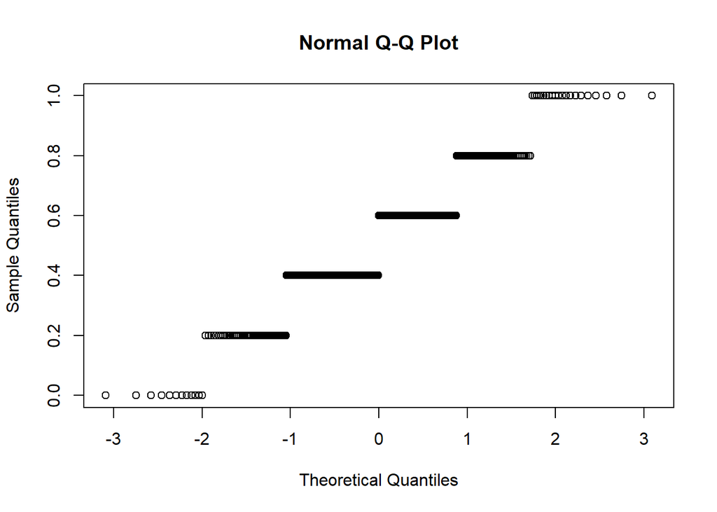

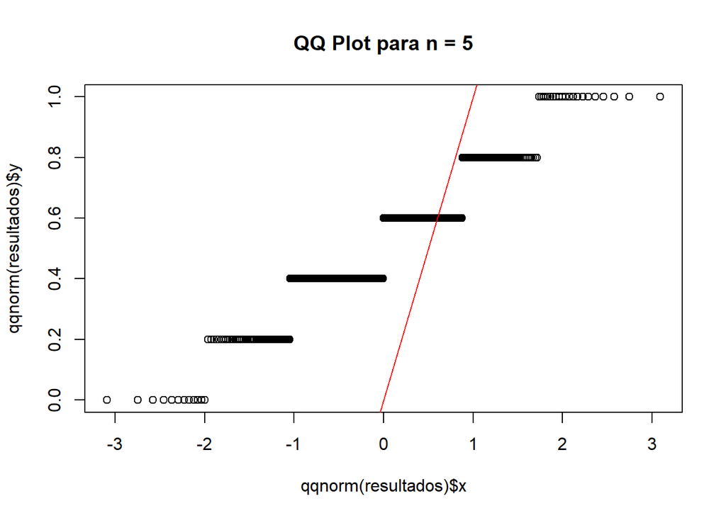

#### Muestra n=10

```
## Tamaño de muestra: 10
## Prueba de Shapiro-Wilk: 5.275183e-10
```

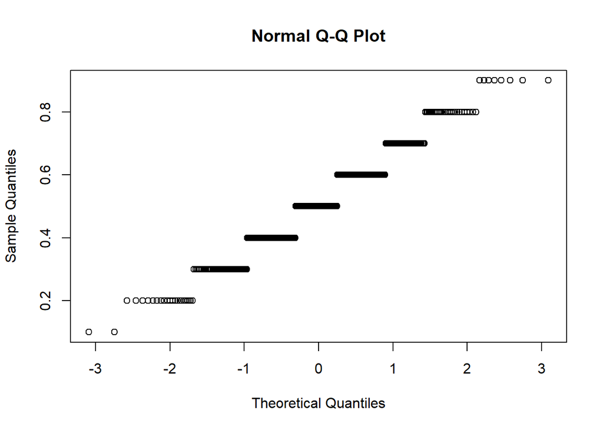

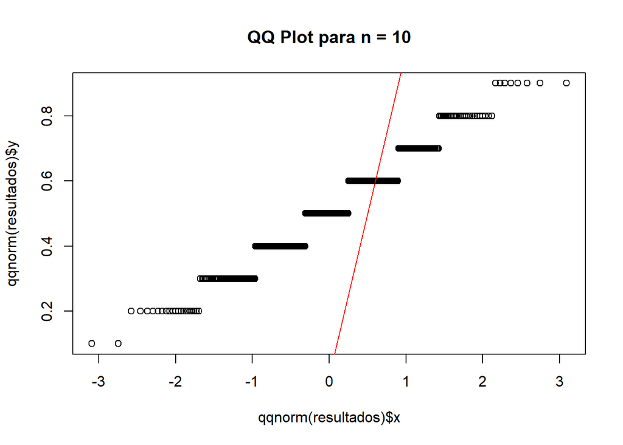

#### Muestra n=15

```
## Tamaño de muestra: 15
## Prueba de Shapiro-Wilk: 1.391385e-07
```

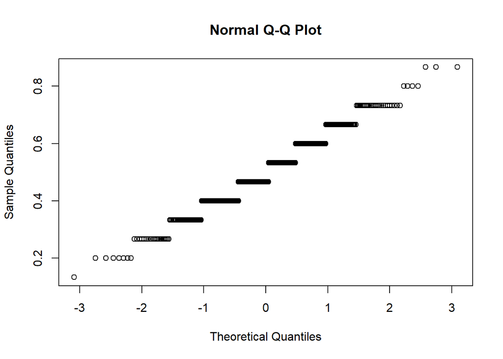

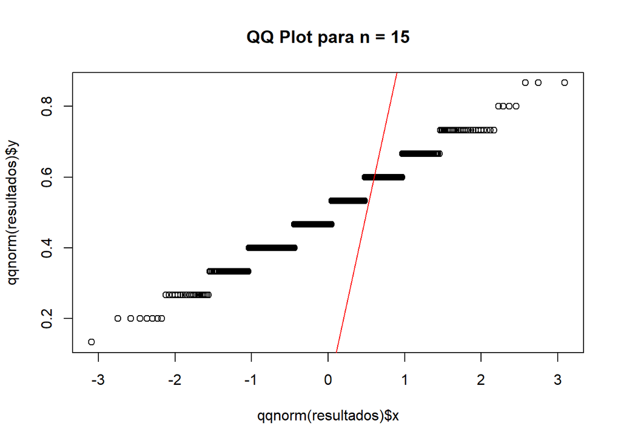

#### Muestra n=20

```
## Tamaño de muestra: 20
## Prueba de Shapiro-Wilk: 1.940473e-06
```

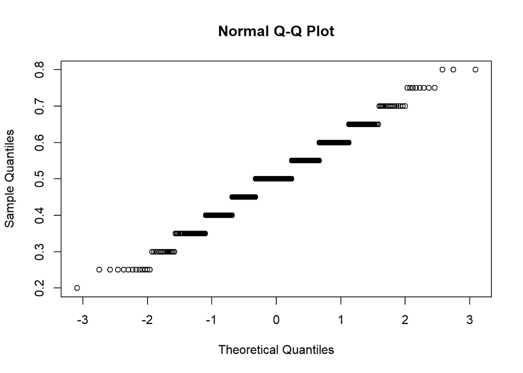

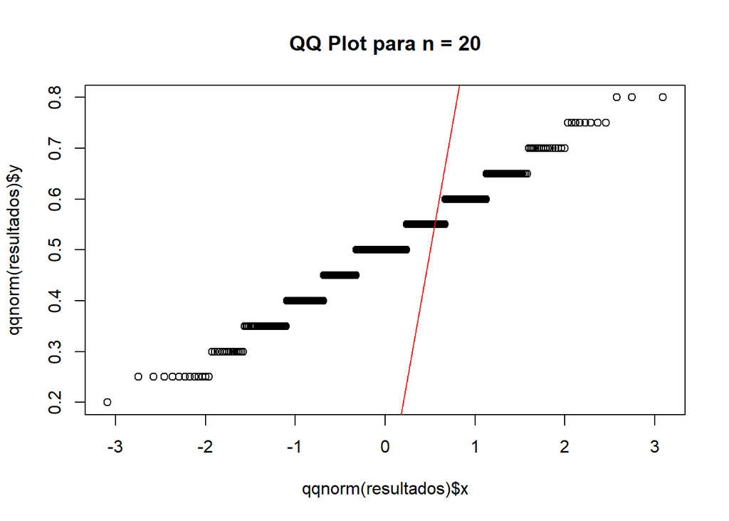

#### Muestra n=30

```
## Tamaño de muestra: 30
## Prueba de Shapiro-Wilk: 7.097915e-05
```

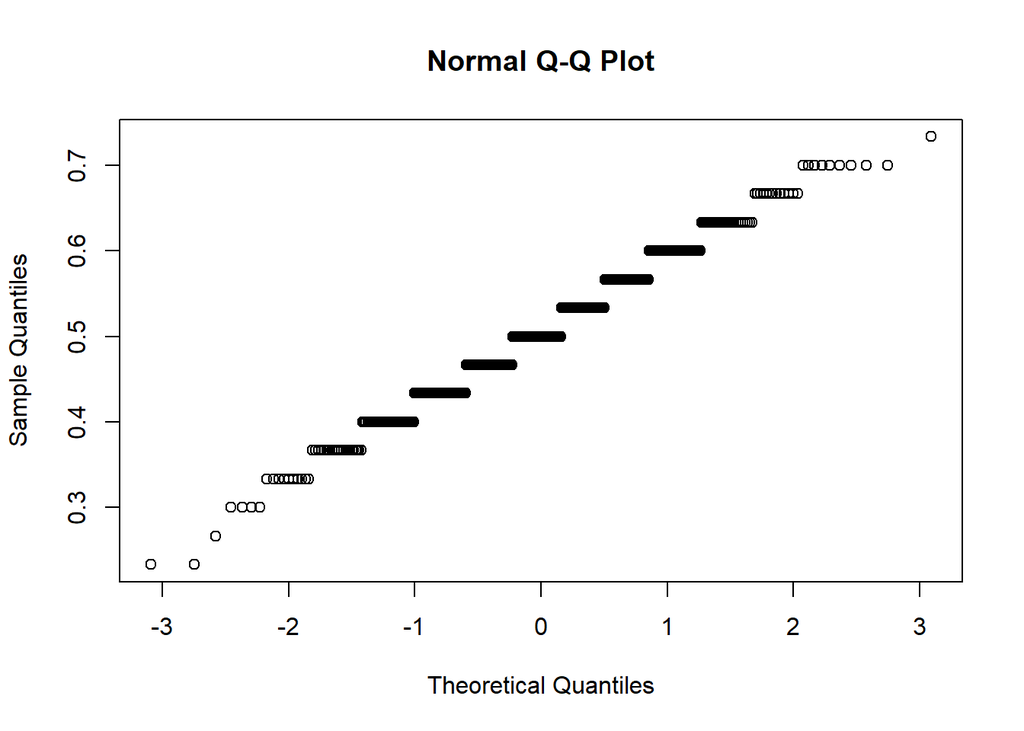

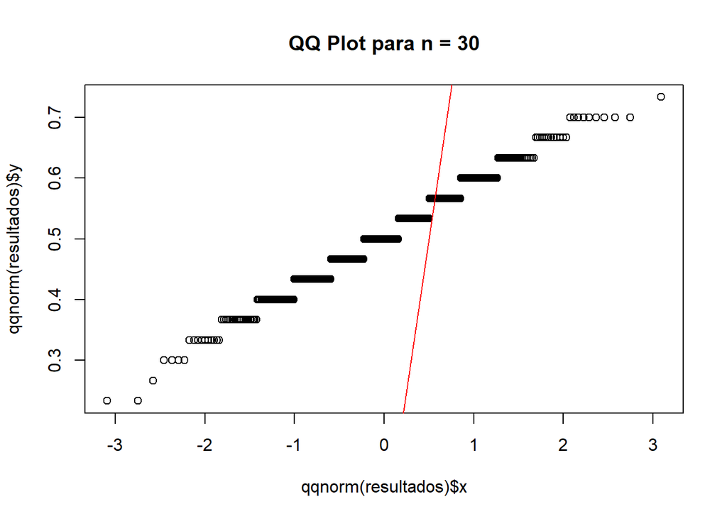

#### Muestra n=50

```
## Tamaño de muestra: 50
## Prueba de Shapiro-Wilk: 0.001786541
```

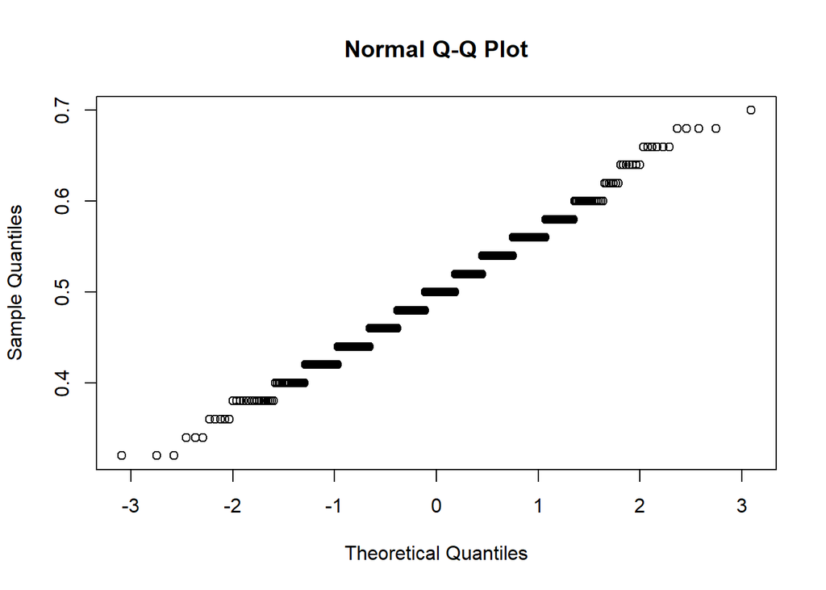

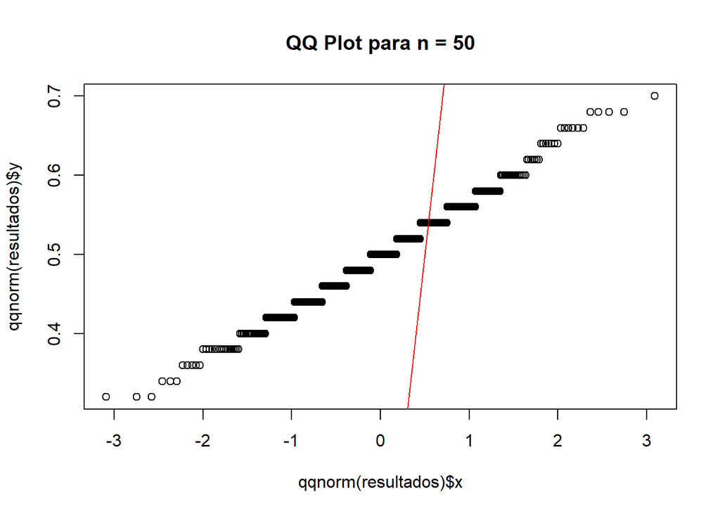

#### Muestra n=60

```
## Tamaño de muestra: 60
## Prueba de Shapiro-Wilk: 0.001272574
```

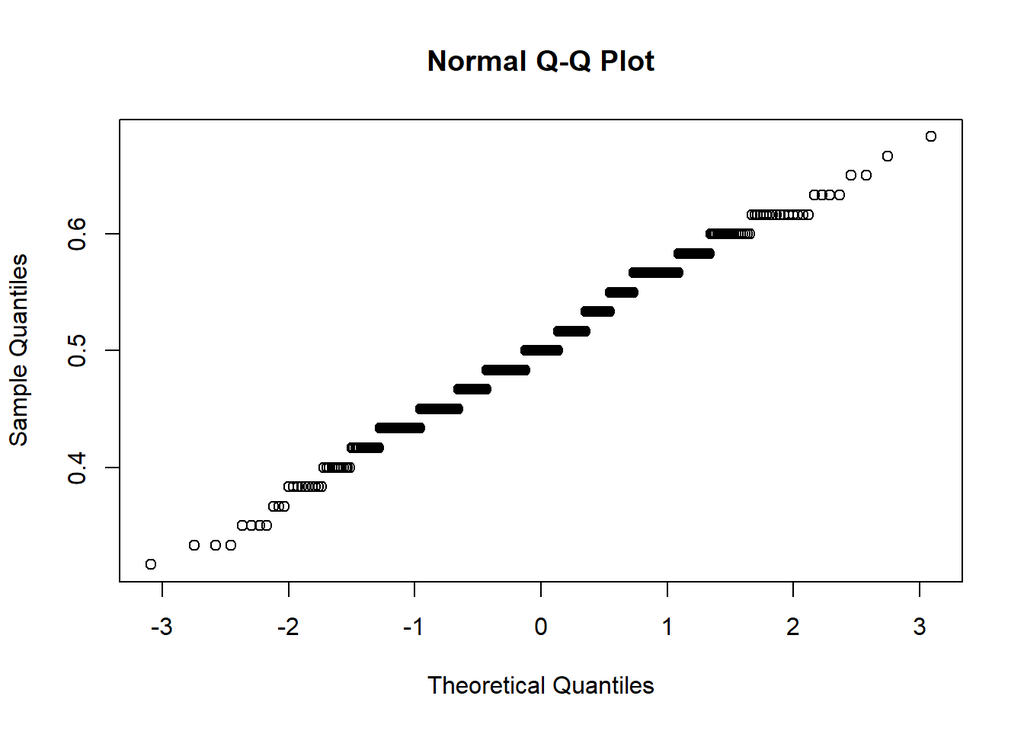

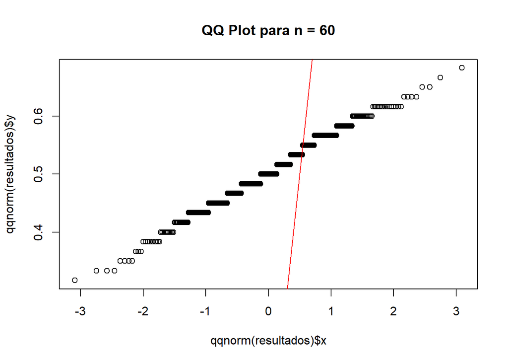

#### Muestra n=100

```
## Tamaño de muestra: 100
## Prueba de Shapiro-Wilk: 0.02622095
```

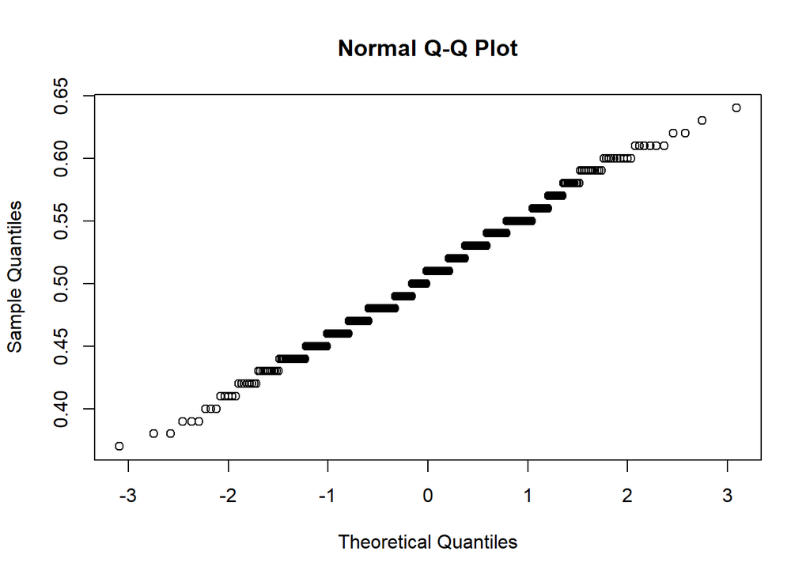

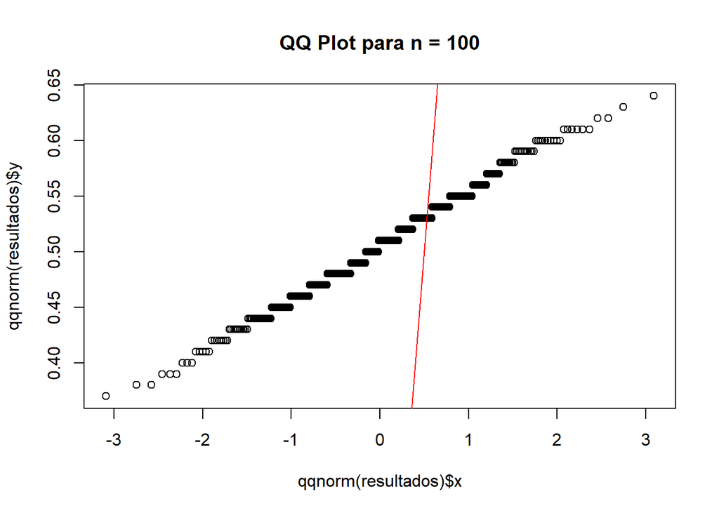

#### Muestra n=200

```
## Tamaño de muestra: 200
## Prueba de Shapiro-Wilk: 0.1163573
```

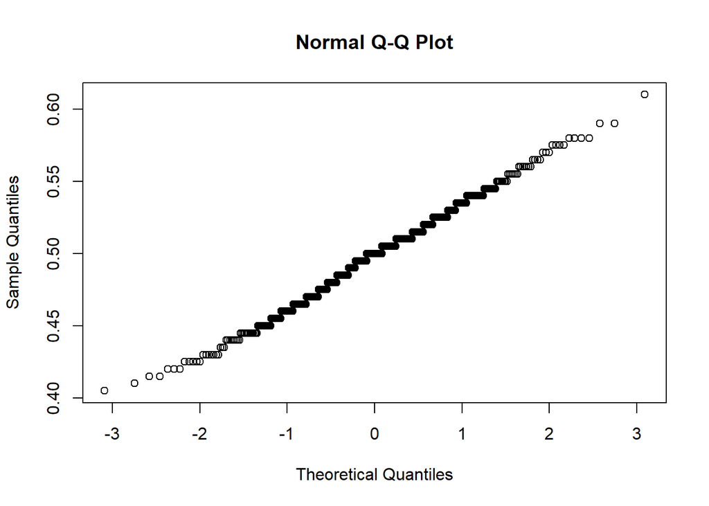

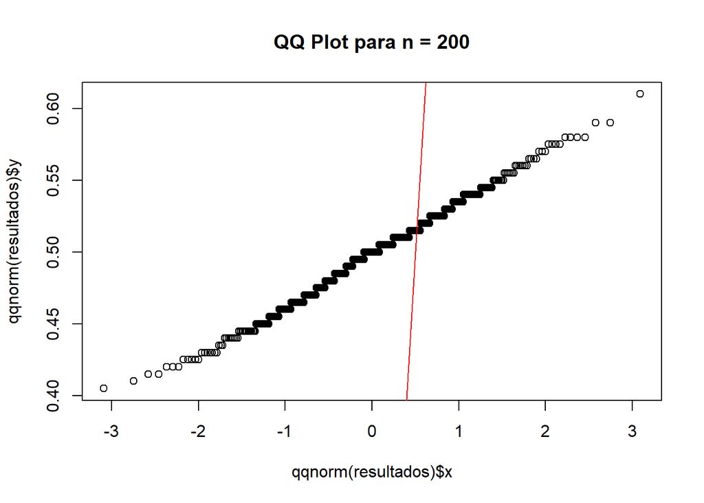

#### Muestra n=500

```
## Tamaño de muestra: 500
## Prueba de Shapiro-Wilk: 0.754305
```

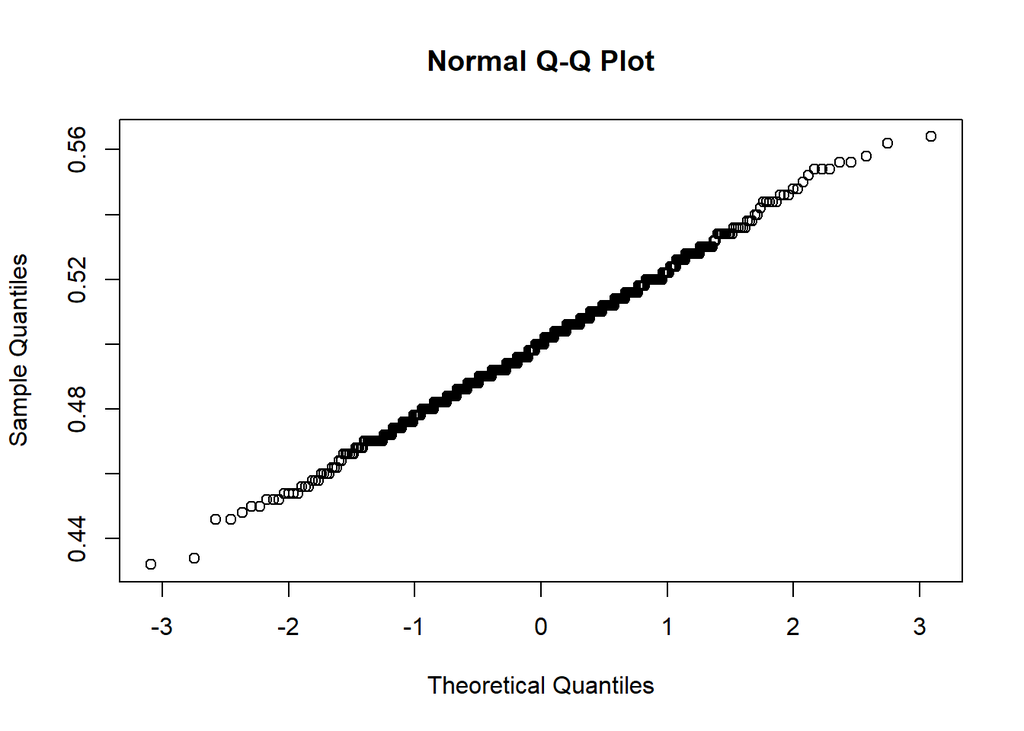

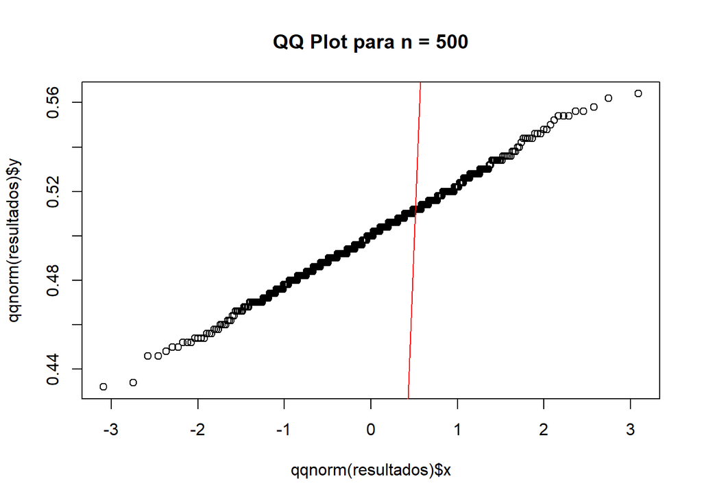

##### 5. Repita toda la simulación (puntos 1 – 4), pero ahora para lotes con 10% de plantas enfermas y de nuevo para lotes con un 90% de plantas enfermas. Concluya sobre los resultados del ejercicio.

```r
# Porcentaje de plantas enfermas 10% y 90%
porcentajes_enfermas <- c(10, 90)

# Realizar la simulación para cada porcentaje de plantas enfermas
for (p in porcentajes_enfermas) {
	# Generar una población con el porcentaje de plantas enfermas dado
	poblacion <- rep(c(0, 1), each = 500 * (p / 100))

	cat("Porcentaje de plantas enfermas:", p, "%\n")

	# Repetir los puntos b y c
	resultados <- replicate(500, obtener_muestra_p(1000))
	simetria <- mean(resultados) - median(resultados)
	sesgo <- mean(resultados) - (p / 100)
	variabilidad <- var(resultados)

	cat("Simetría:", simetria, "\n")
	cat("Sesgo:", sesgo, "\n")
	cat("Variabilidad:", variabilidad, "\n")

	# Repetir el punto d
	for (n in tamanos_muestra) {
		analisis_normalidad(n)
	}

	cat("\n")
}
```

```
## Porcentaje de plantas enfermas: 10 %
## Simetría: 0.000346
## Sesgo: 0.399346
## Variabilidad: 0.0002255454
```

#### Muestra n=5

```
## Tamaño de muestra: 5
## Prueba de Shapiro-Wilk: 4.61101e-15
```

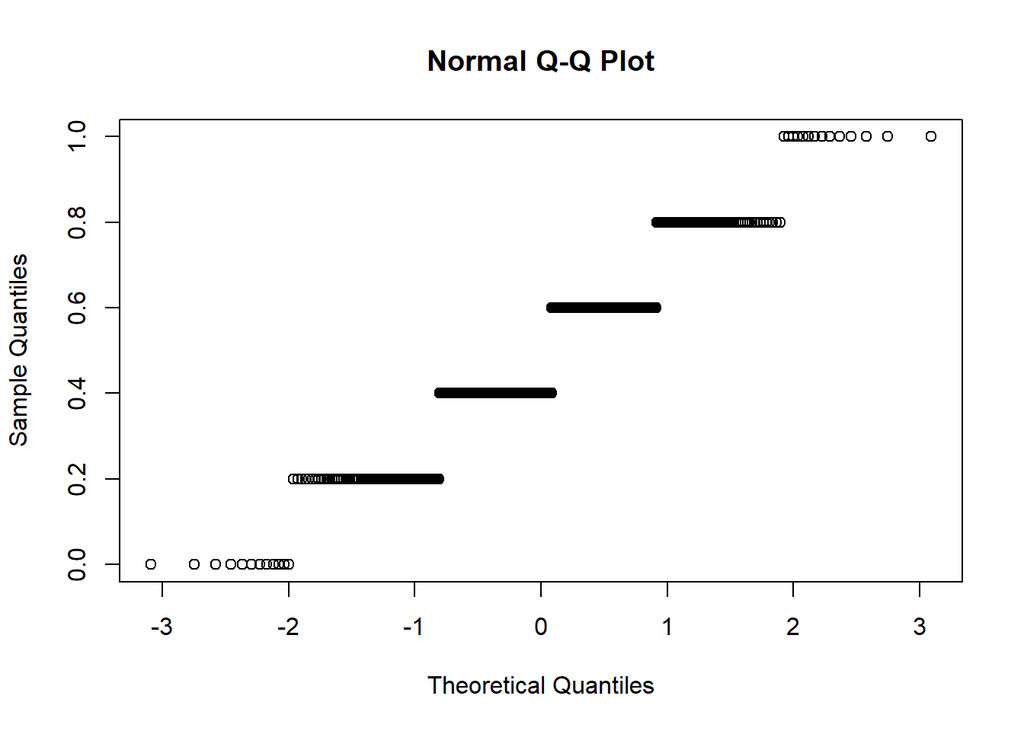

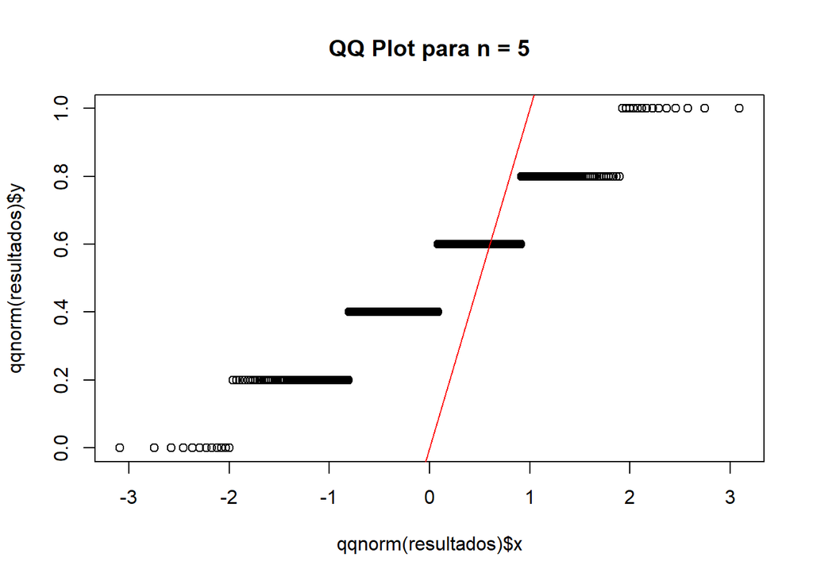

#### Muestra n=10

```
## Tamaño de muestra: 10
## Prueba de Shapiro-Wilk: 1.441791e-09
```

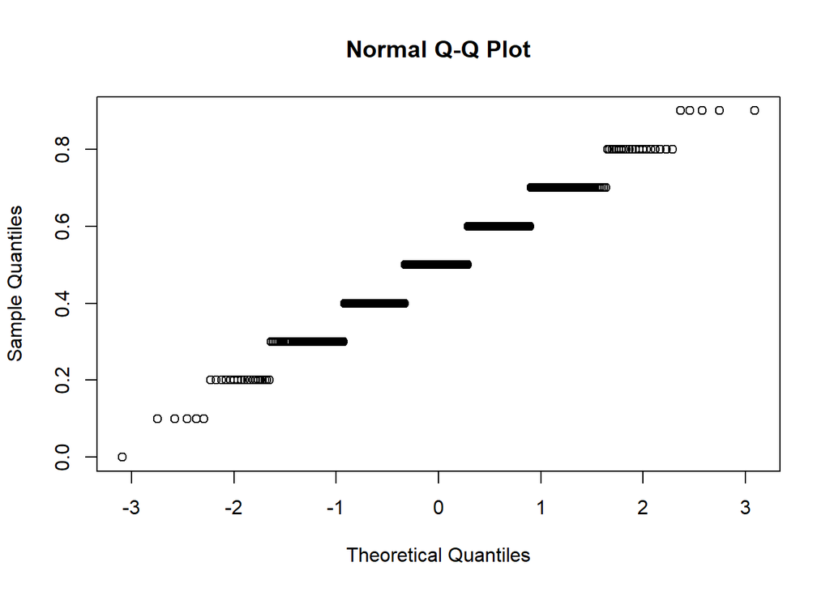

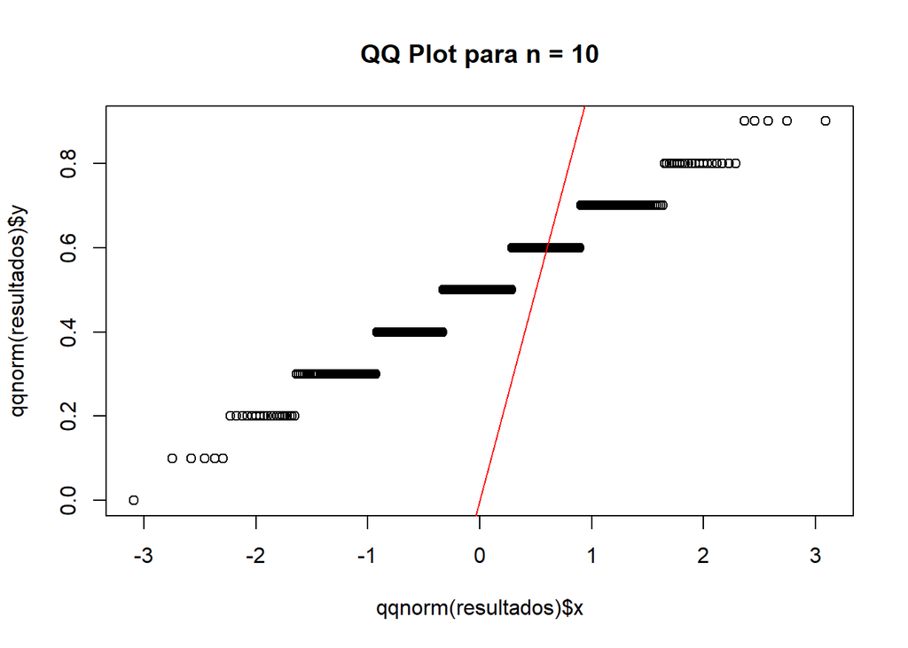

#### Muestra n=15

```
## Tamaño de muestra: 15
## Prueba de Shapiro-Wilk: 2.163932e-07
```

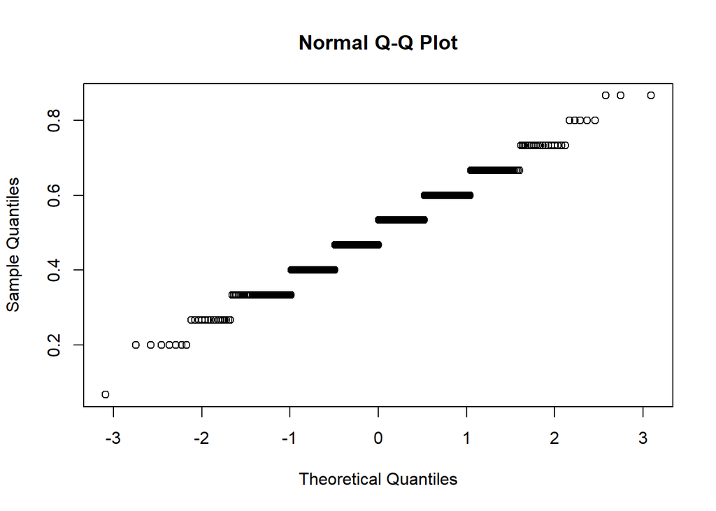

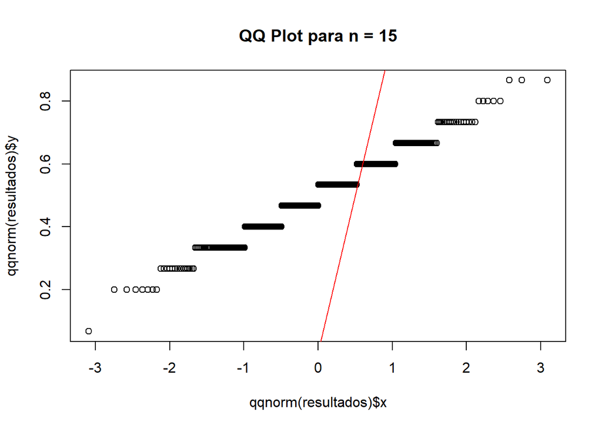

#### Muestra n=20

```
## Tamaño de muestra: 20
## Prueba de Shapiro-Wilk: 3.423357e-06
```

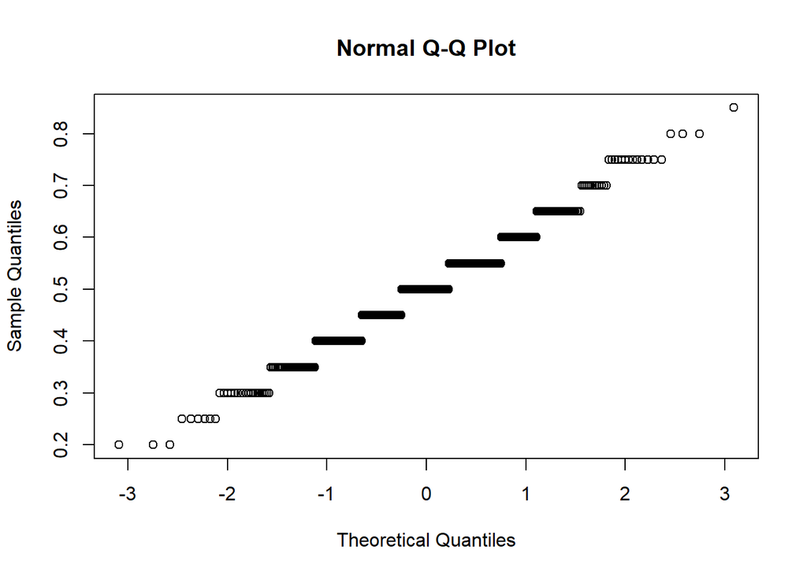

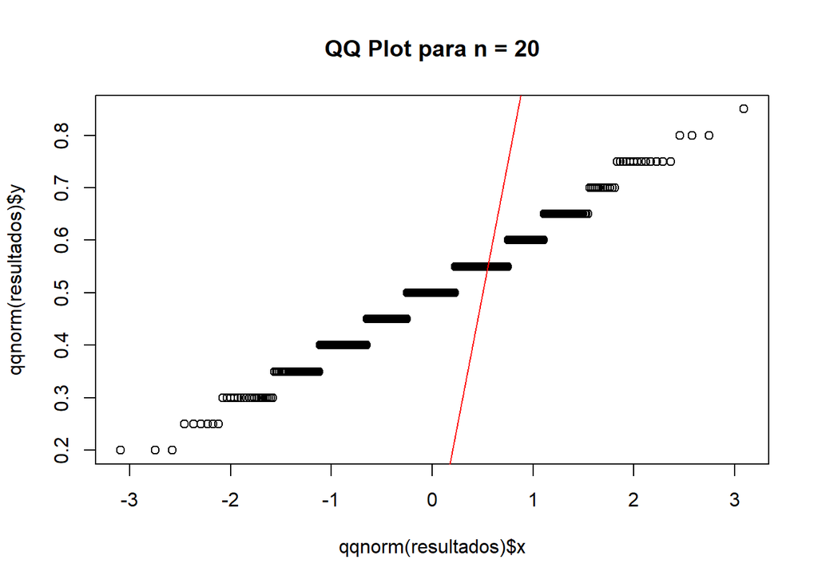

#### Muestra n=30

```
## Tamaño de muestra: 30
## Prueba de Shapiro-Wilk: 5.389487e-05
```

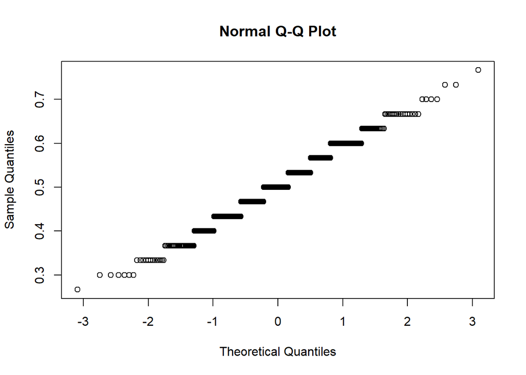

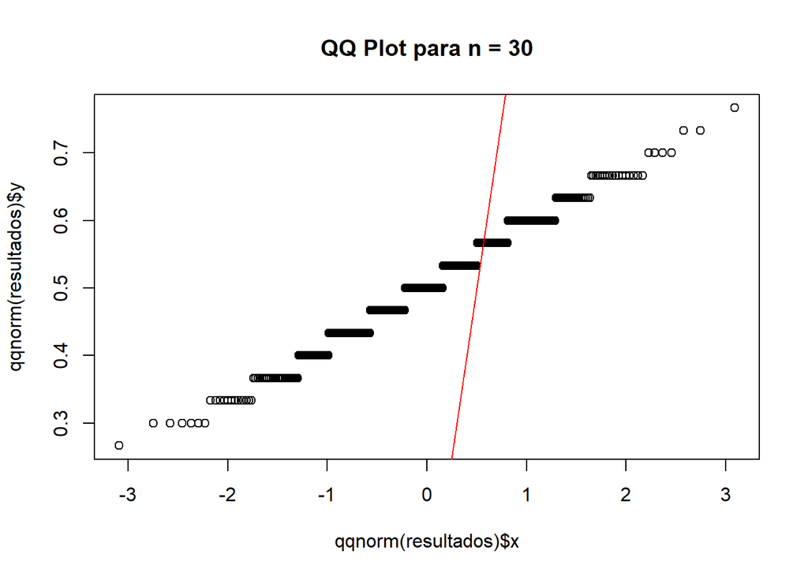

#### Muestra n=50

```
## Tamaño de muestra: 50
## Prueba de Shapiro-Wilk: 0.01292213
```

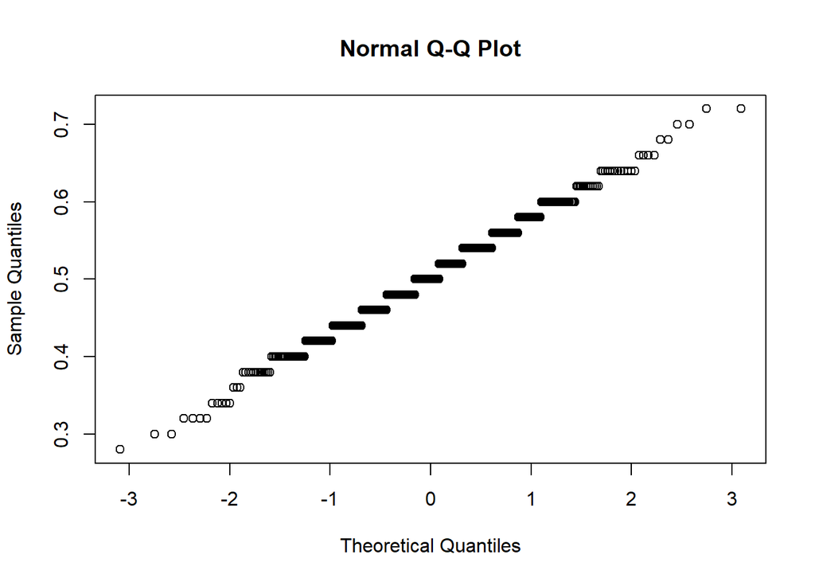

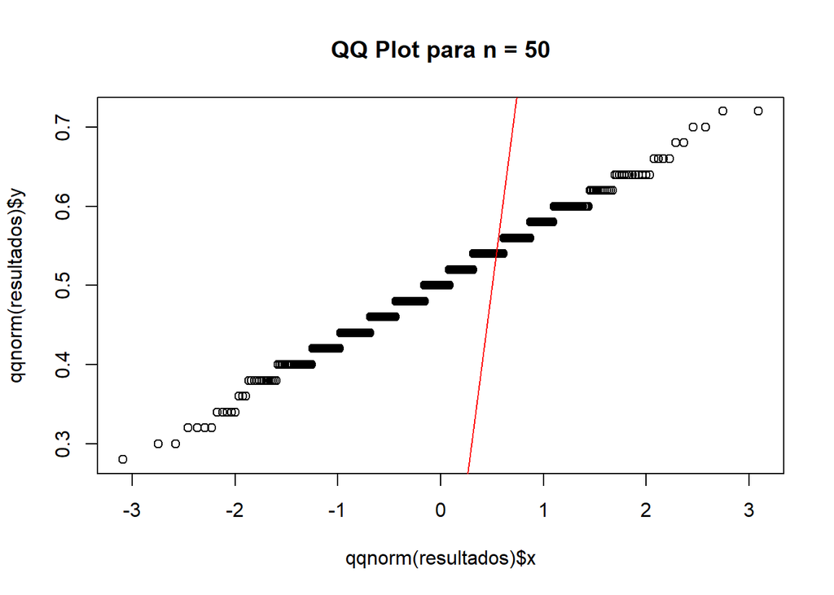

#### Muestra n=60

```
## Tamaño de muestra: 60
## Prueba de Shapiro-Wilk: 0.001087931
```

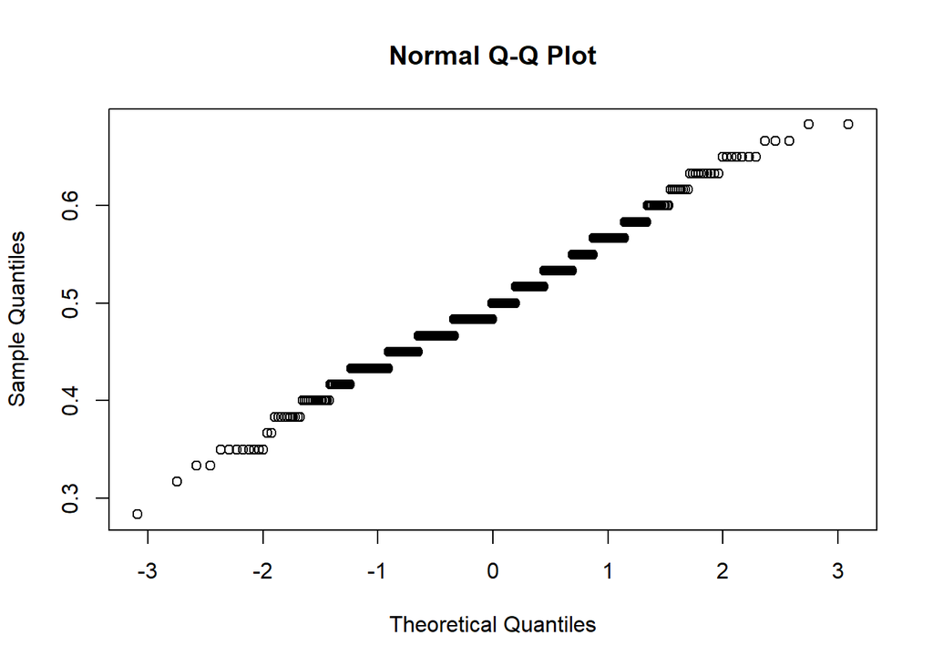

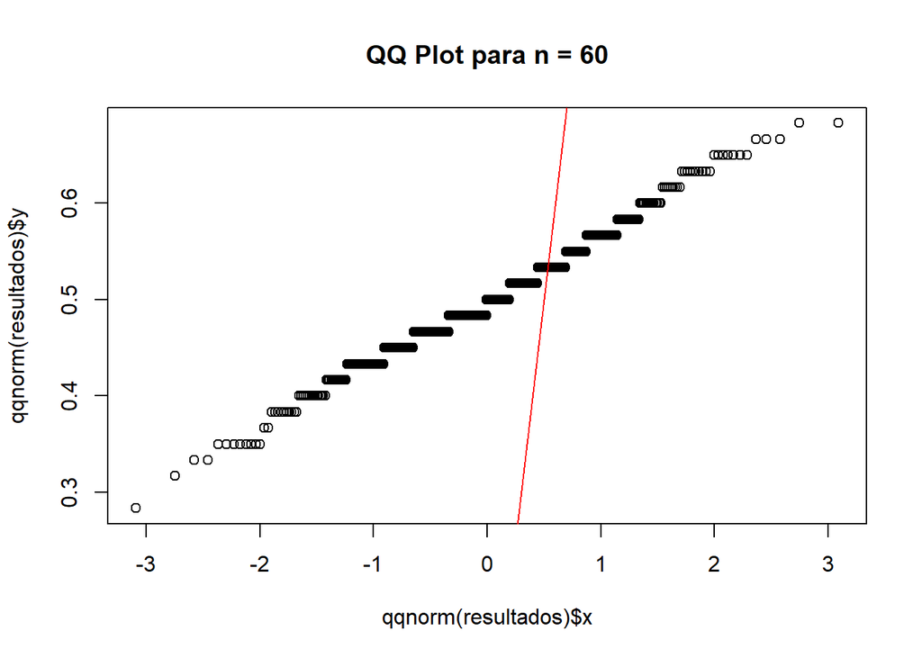

#### Muestra n=100

```
## Tamaño de muestra: 100
## Prueba de Shapiro-Wilk: 0.01560404
```

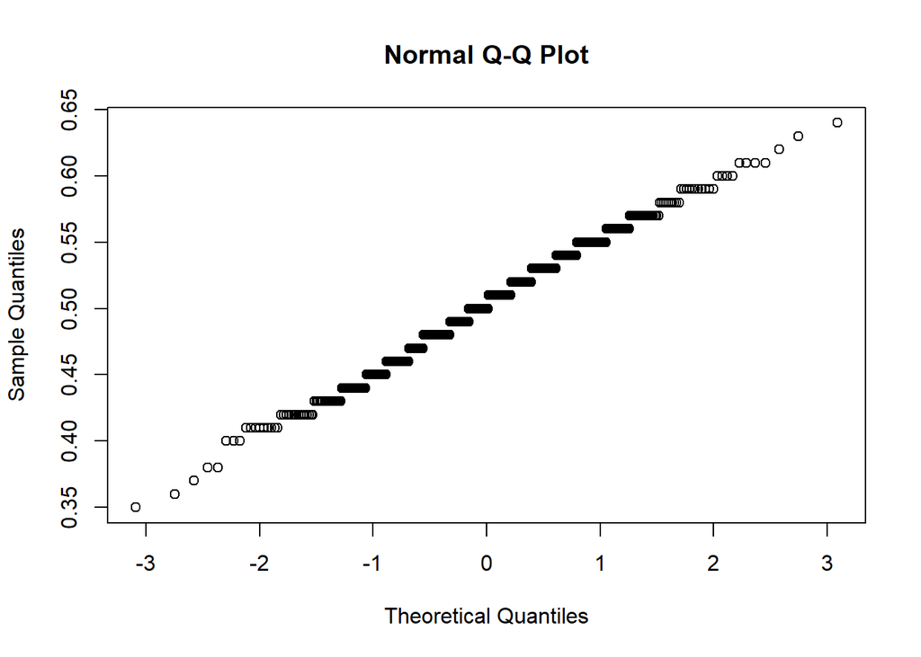

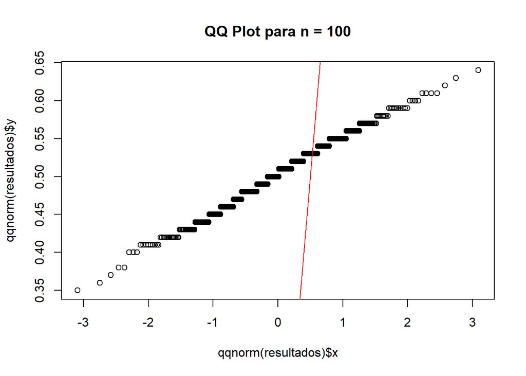

#### Muestra n=200

```
## Tamaño de muestra: 200
## Prueba de Shapiro-Wilk: 0.1583855
```

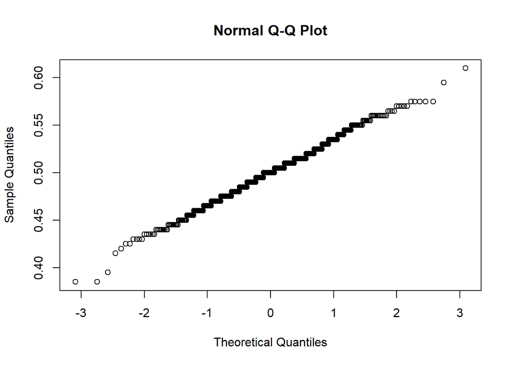

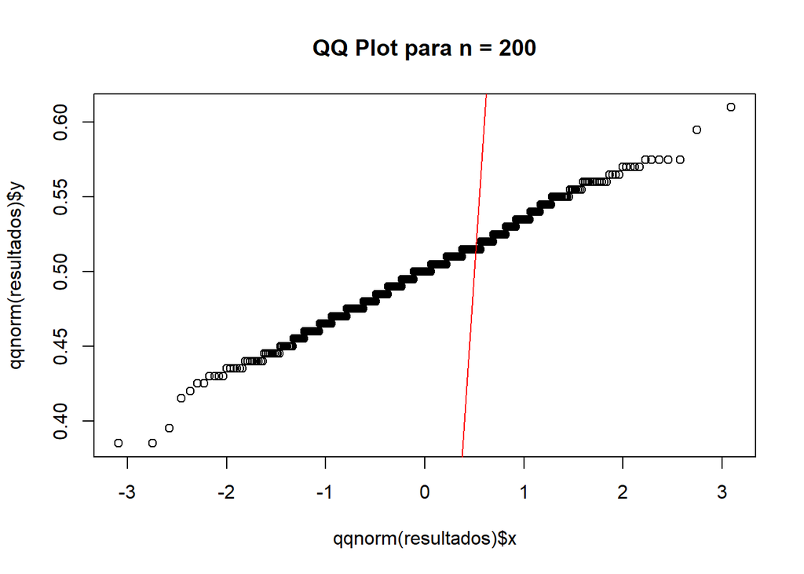

#### Muestra n=500

```
## Tamaño de muestra: 500
## Prueba de Shapiro-Wilk: 0.3500382
```

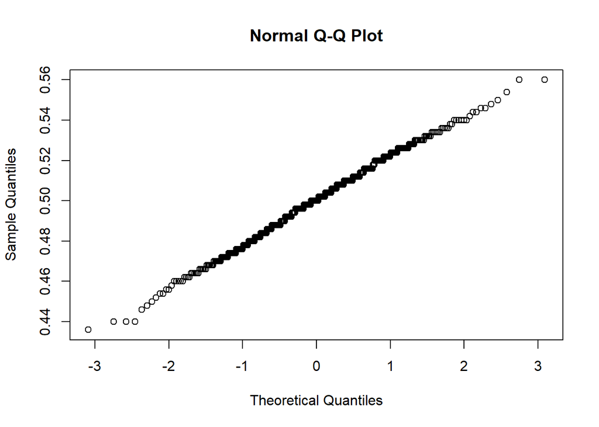

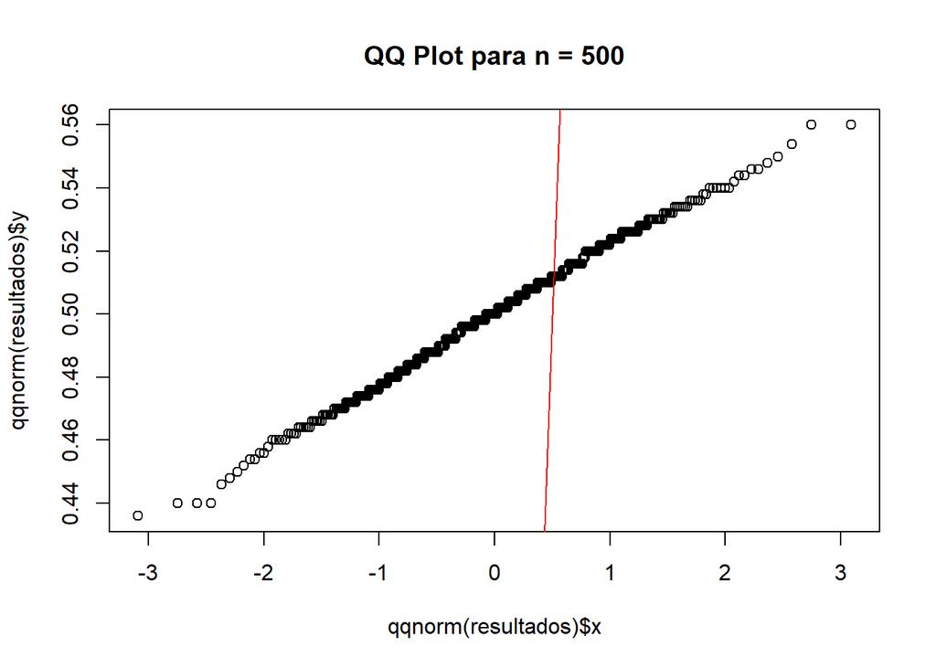

#### Plantas enfermas: 90 %

```
## Porcentaje de plantas enfermas: 90 %
## Simetría: 0.00148
## Sesgo: -0.39952
## Variabilidad: 0.000258214
```

#### Muestra n=5

```
## Tamaño de muestra: 5
## Prueba de Shapiro-Wilk: 2.801733e-14
```

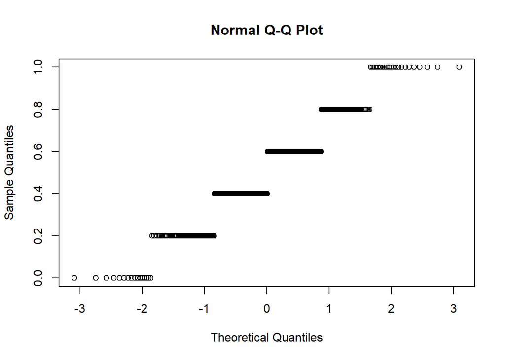

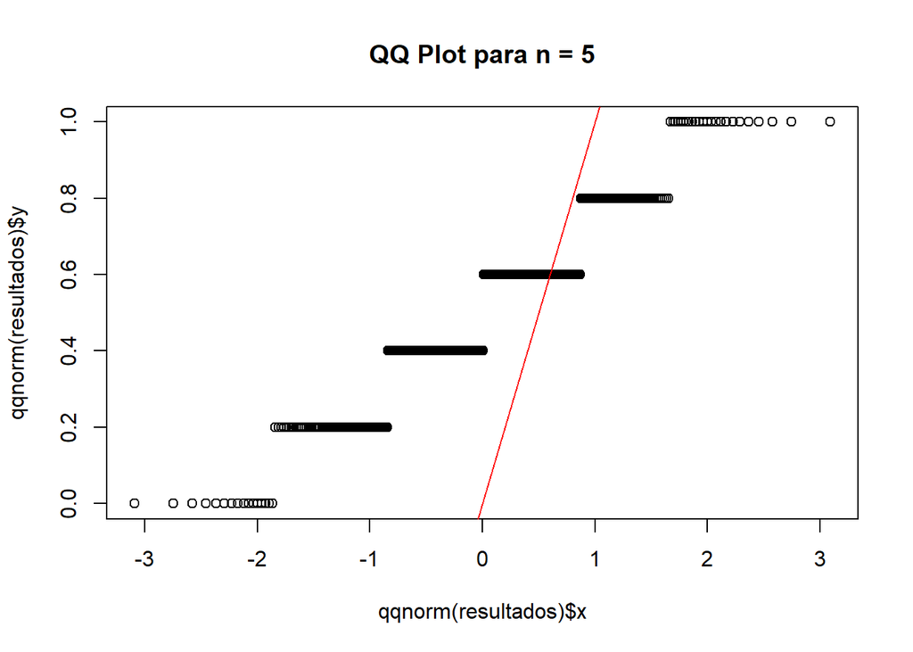

#### Muestra n=10

```
## Tamaño de muestra: 10
## Prueba de Shapiro-Wilk: 5.945476e-10
```

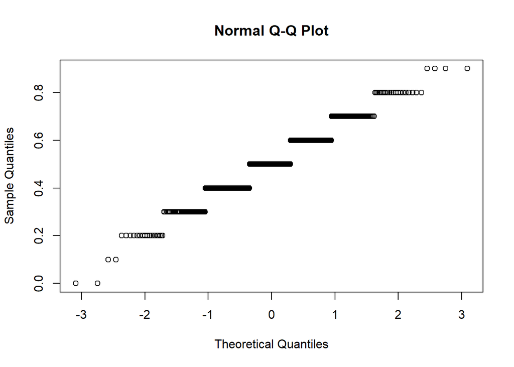

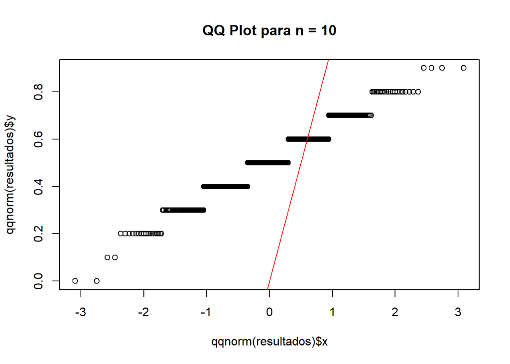

#### Muestra n=15

```
## Tamaño de muestra: 15
## Prueba de Shapiro-Wilk: 1.075777e-07
```

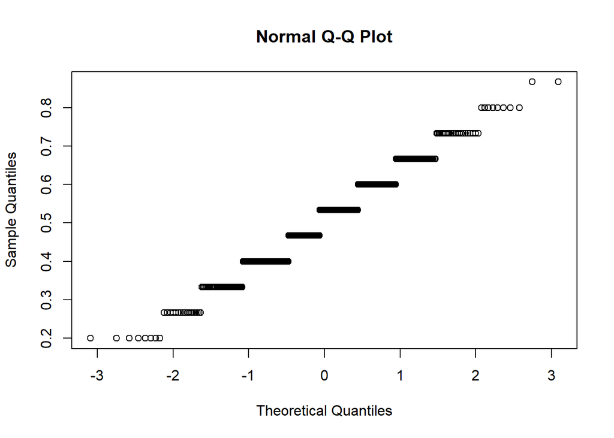

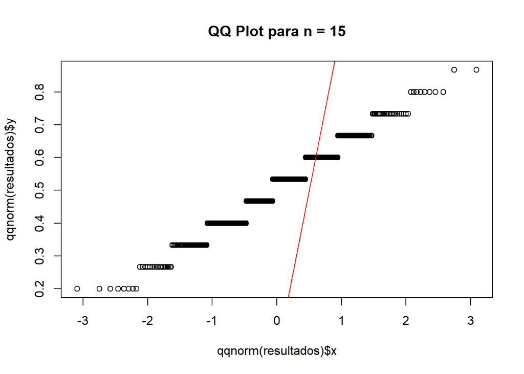

#### Muestra n=20

```
## Tamaño de muestra: 20
## Prueba de Shapiro-Wilk: 5.873511e-06
```

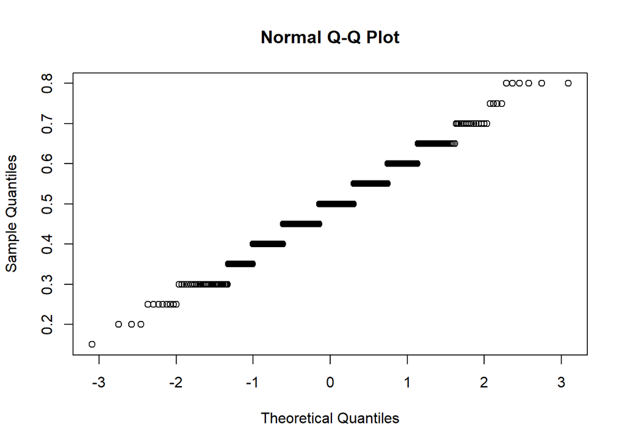

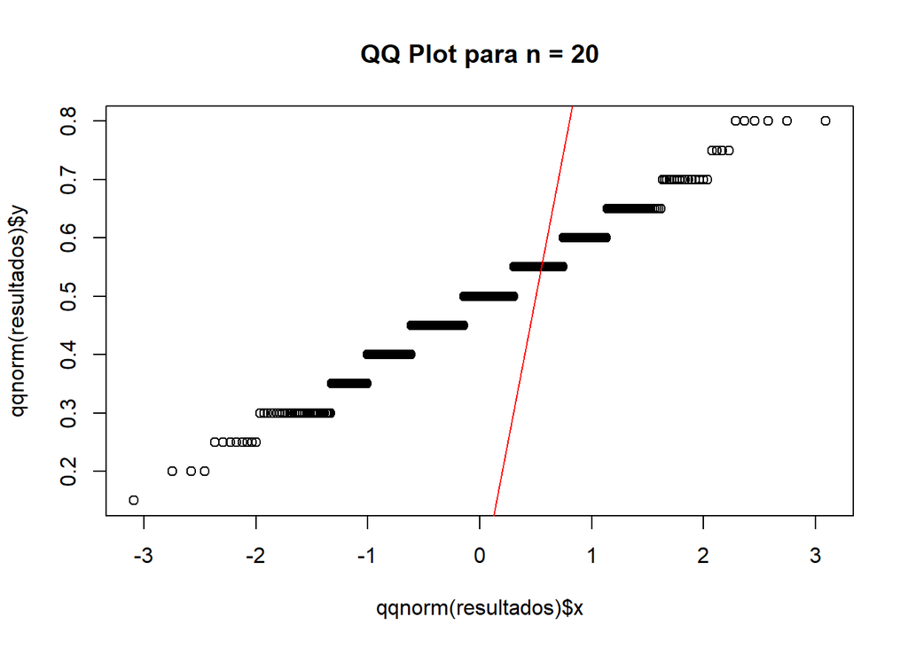

#### Muestra n=30

```
## Tamaño de muestra: 30
## Prueba de Shapiro-Wilk: 7.297211e-06
```

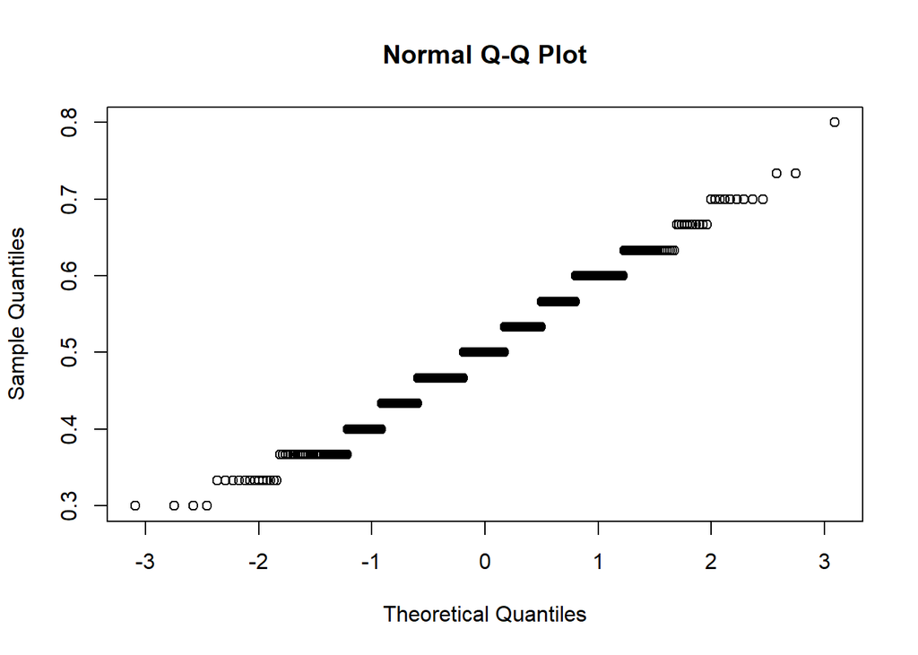

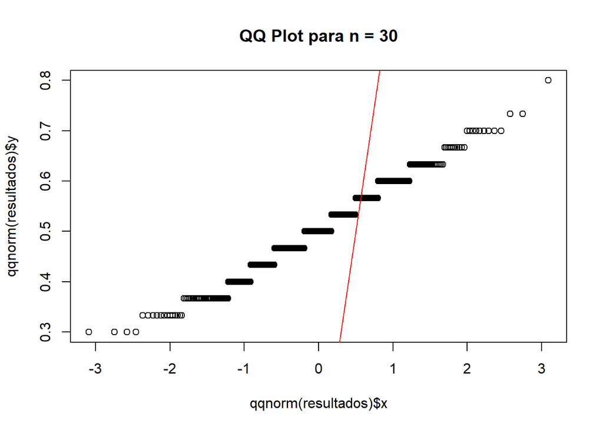

#### Muestra n=50

```
## Tamaño de muestra: 50
## Prueba de Shapiro-Wilk: 0.004564279
```

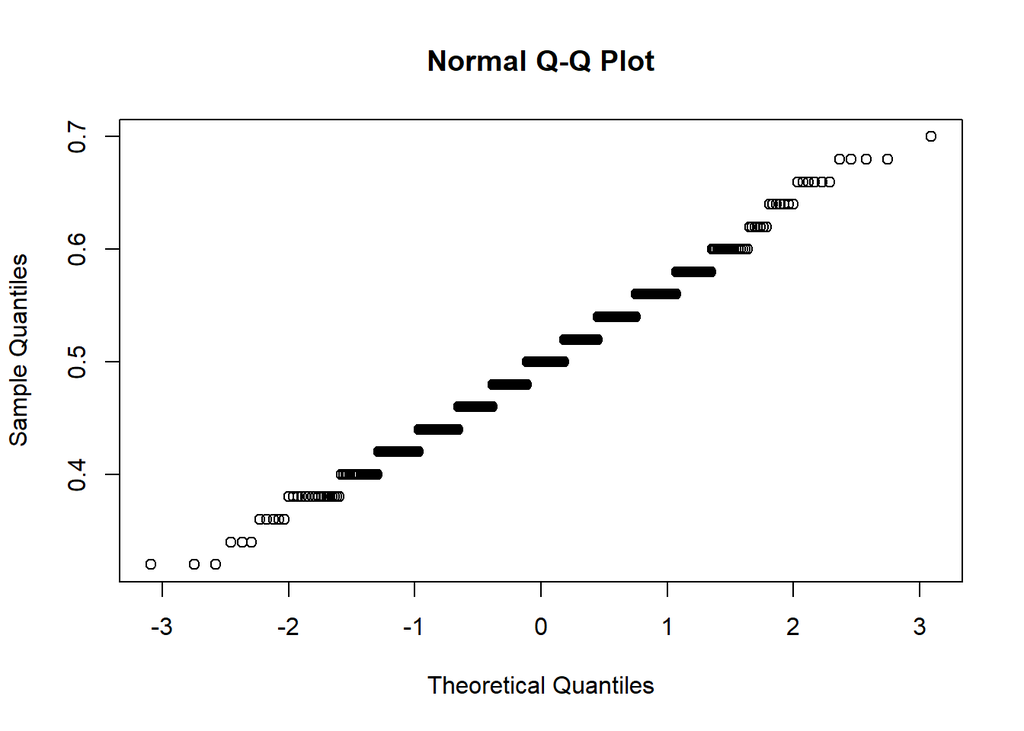

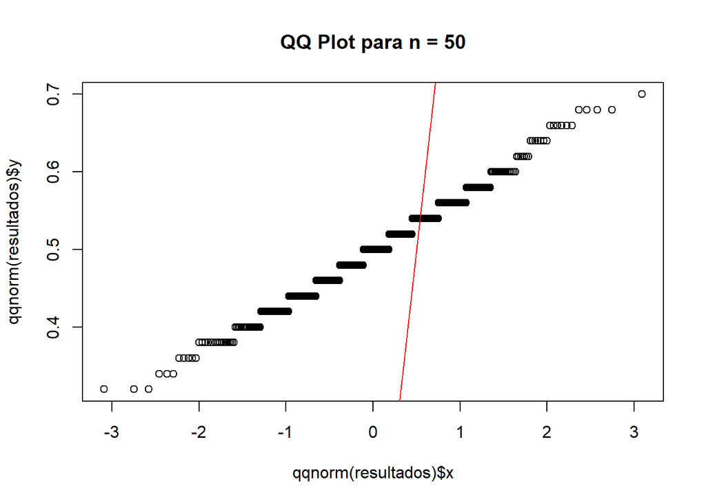

#### Muestra n=60

```
## Tamaño de muestra: 60
## Prueba de Shapiro-Wilk: 0.000513014
```

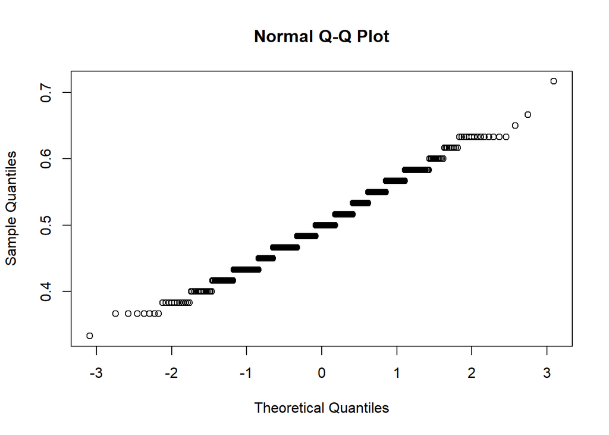

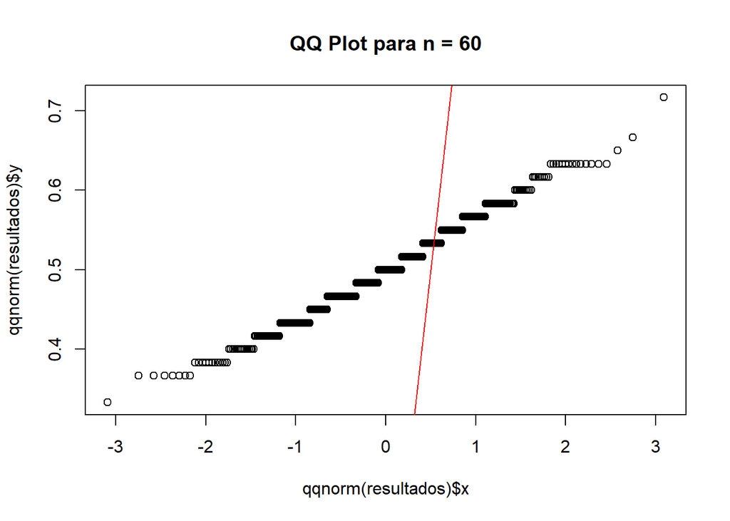

#### Muestra n=100

```
## Tamaño de muestra: 100
## Prueba de Shapiro-Wilk: 0.005817537
```

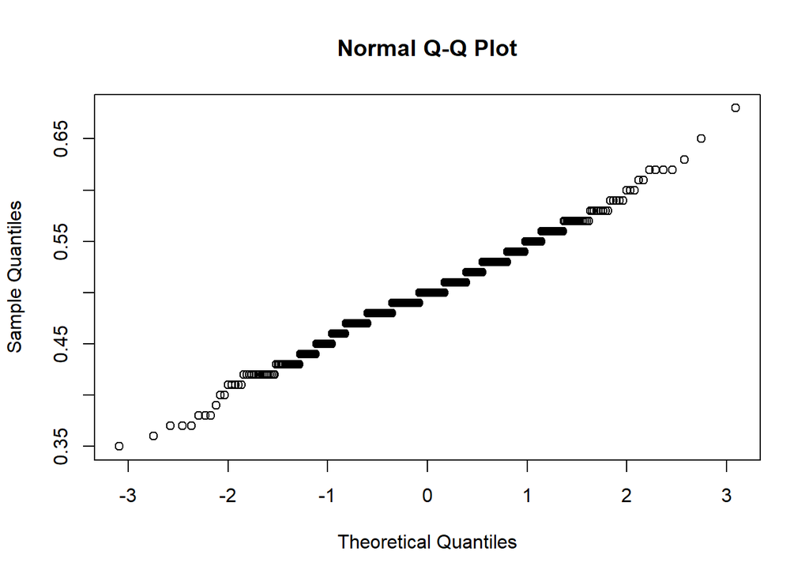

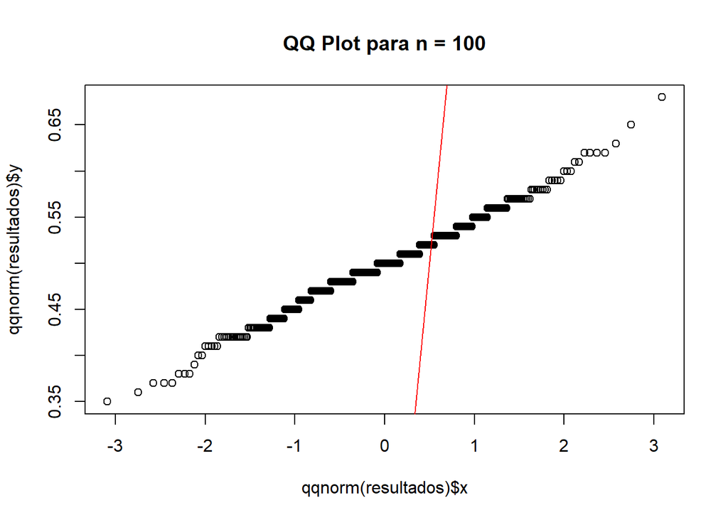

#### Muestra n=200

```
## Tamaño de muestra: 200
## Prueba de Shapiro-Wilk: 0.1008157
```

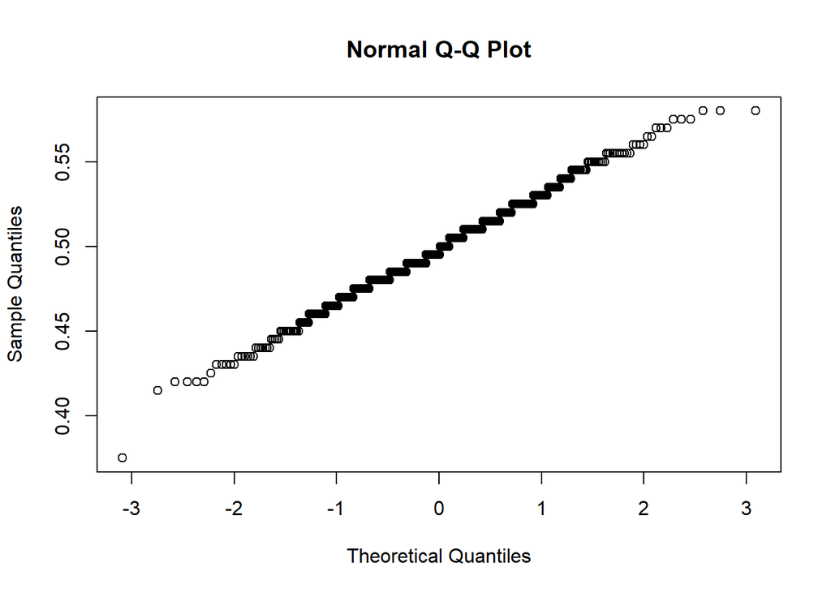

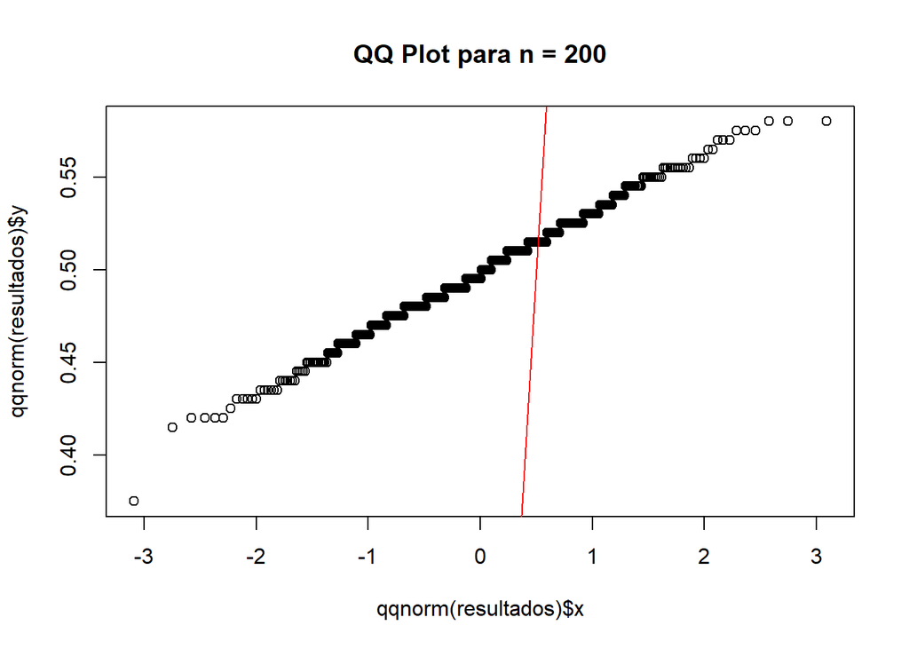

#### Muestra n=500

```
## Tamaño de muestra: 500
## Prueba de Shapiro-Wilk: 0.4206946
```

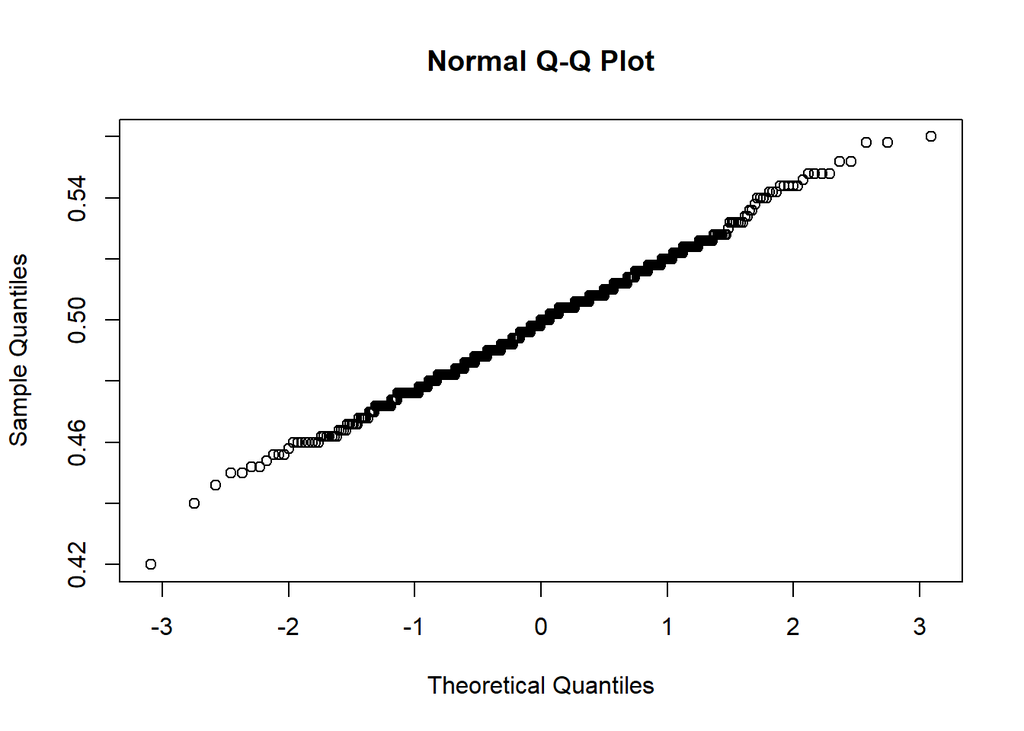

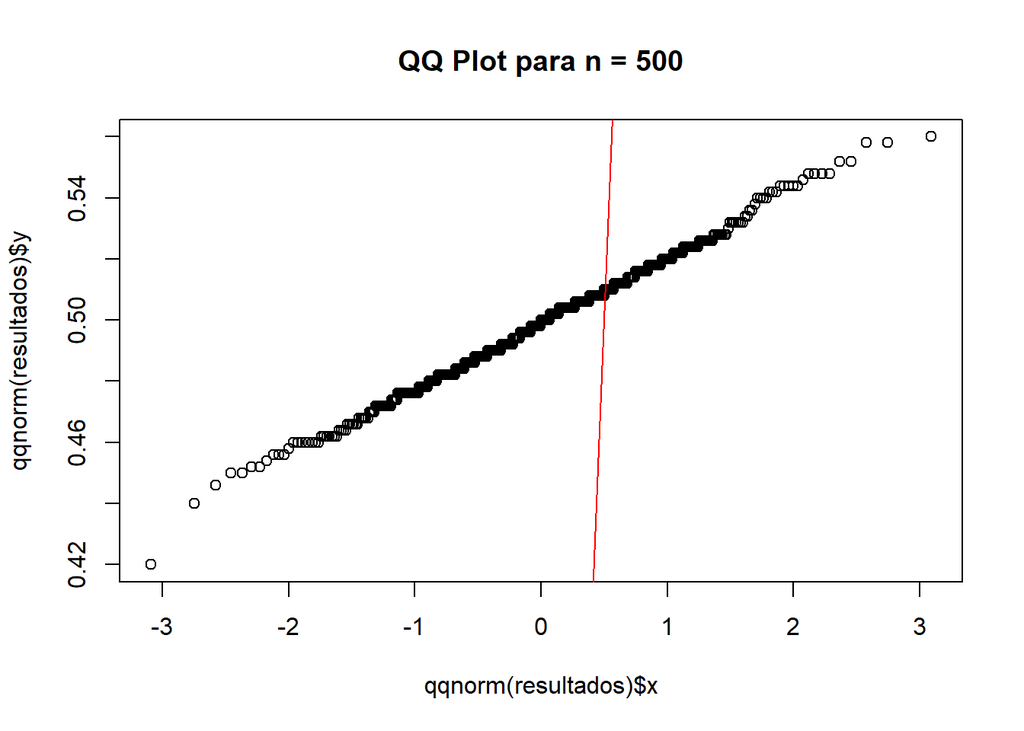

##### Conlusiones

- En la simetría de las muestras, podemos notar que en ambos casos, la simetría es cercana a cero, lo que sugiere que las muestras tienden a distribuirse de manera bastante simétrica alrededor de su media. Esto indica que, en términos generales, no hay un sesgo evidente en la muestra hacia un extremo particular.
- En relación al sesgo, vemos que hay una diferencia significativa entre los dos escenarios. Con un 10% de plantas enfermas, el sesgo es positivo, lo que sugiere una tendencia a sobreestimar el porcentaje de plantas enfermas en la población. Por otro lado, con un 90% de plantas enfermas, el sesgo es negativo, lo que indica una tendencia a subestimar el porcentaje de plantas enfermas en la población. Esto sugiere que la precisión de las estimaciones varía según el nivel de enfermedad en la población.
- En cuanto a la variabilidad de las muestras, observamos que es relativamente baja en ambos casos, lo que indica que las muestras tienden a ser coherentes entre sí y cercanas a la media poblacional.